# Lesson 3

Timothy Luna

8/20/2019

# Filtering

Helpful reading https://docs.opencv.org/3.1.0/d4/d13/tutorial_py_filtering.html.

Remember that an image can be represented by a two dimensional construct where we can talk about x and y coordinates or i, j coordinates in an array.

## Gaussian Noise

Previously we discussed adding noise to a function; keep in mind that you must consider the size of $\sigma$ with respect to the range of values in the image.

Suppose there is noise in the image and you want to remove the noise; how would you go about that?

One way would be to replace the value in each pixel by the average of all the pixels around it. This is a local, or moving, average.

Let’s think about this in one dimension. Taking a local average means that we can ‘smooth’ things locally.

Does this make sense? Is it intuitive?

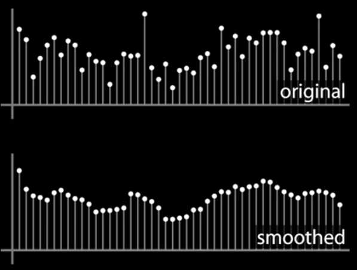

Locally weighted moving average

## Averaging Assumptions

Why was the solution of the one-dimensional problem intuitive? What assumptions were made about pictures and noise?

1. The ‘True’ value of a pixel is likely similar to nearby values.
2. The noise added to each pixel is done independently.

## Quiz: Noise

If noise is just a function added to an image, can we remove by subtracting the noise from the image? I.e., is the operation reversible?

Yes, but without knowing the noise function this is effectively false. Additionally there are nonlinearities from clipping / truncating when conducting addition that are likely non-recoverable.

We can *add* noise to an image via linear superposition of a noise function $\vec \eta$. In practice this means that we can ‘clean up’ noise in an image by linear superposition of $-\vec \eta$ if the function is known or we can get a pretty close guess.

## Weighted Moving Average

Revisiting the one dimensional weighted average; we can construct the local average with a weighting scheme where the weights are some function of nearby points. i.e. …

$I_i = \sum_{j=-2}^2 W_{j+2}I_{i+j}$ where $W=\frac{1}{16}\begin{bmatrix}1 & 4 & 6 & 4 & 1\end{bmatrix}$

This is *one* purely arbitrary set of weights. You can notice that the non uniform weights produce a smoother, more continuous, surface. This corresponds to an assumption that *nearer pixels are more related*.

When computing a moving average amny people in practice tend to use odd sized sets of weights to produce a centered and symmetric filter. Remember that in real life your filter weights can be an *arbitrary function* and don’t necessarily need to be a small and symmetric moving window.

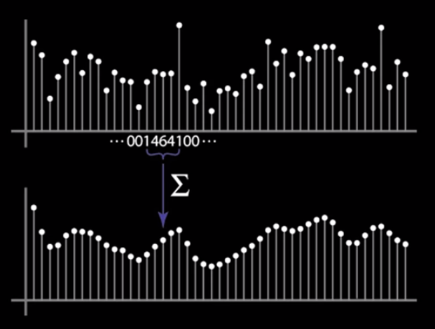

Smoothed / Weighted moving average

## Moving Average in 2D

The same concept as before can now be extended to a two dimensional construct.

$I_{(i,j)} = \sum_{i=-2}^2 \sum_{j=-2}^2 W_{i+2,j+2} I_{(i,j)}$ where $W=\frac{1}{25}J_5$ [^2]

## Correlation Filtering

In more abstract terms (*and using actually correct notation*) the moving average above is called a correlation filter with uniform weights.

Assuming the averaging window is $[2k+1 \times 2k+1]$

$$G[i,j] = \frac{1}{(2k+1)^2} \sum_{u=-k}^k \sum_{v=-k}^k F[i + u, j+v]$$

This loops over all the nearby pixels, sums them all, and divides by the total number of pixels averaged over.

What about non-uniform weights? Using the same concept as before but using *correct terminology*:

$$G[i,j] = \sum_{u=-k}^k \sum_{v=-k}^k H[u,v] F[i + u, j+v]$$

This is called cross correlation and is commonly seen as $G=H\otimes F$.

G is the cross correlation of H with F.

H can be called the kernel, or the mask, or the coefficients. It is the matrix of weights. This kernel has little to do with machine learning kernels.

These non-uniform weights are arbitrary; they could resemble a normal distribution.

## Averaging Filter

What makes a good kernel? Returning to the averaging filter, how does that affect an image? The averaging filter can make an ugly, blurry, image.

What went wrong? Imagine that you have a single point of light and it’s blurred, what does it look like? Solid in the center fading as you radiate out.

## Quiz: Blur

To blur a single pixel into a ‘blurry’ spot, we would need to filter the spot with a matrix of coefficients that resembles a blurry spot; this matrix would have higher values closer to the spot and lower farther away.

Any set of uniform weights is going to *mute* the spot and bring up the darkness a little bit lighter.

## Gaussian Filter

What would this function look like? A normal distribution! This gaussian filter resembles a normal distribution by having peaks in the middle and values falling off radially outward.

$$\frac{1}{16}\begin{bmatrix} 1 & 2 & 1 \\ 2 & 4 & 2 \\ 1 & 2 & 1\end{bmatrix}$$

This sample set of weights is normalized and resembles a two dimensional gaussian probability distribution.

This filter isn’t a *great* gaussian because it’s so small and so roughly discretized, but a circularly symmetric two dimensional Gaussian *function* $h(u,v)=\frac{1}{2\pi \sigma^2}-\frac{u^2+v^2}{\sigma^2}$ makes a *great* blur.

## Variance or Standard Deviation

The previous Gaussian was isotropic (circularly symmetric) with one parameter ($\sigma$).

In computation we have to worry about $\sigma$ and the size of the matrix. The variance (or standard deviation) is the amount of smoothing and denotes the size of the smoothing in the filter. Two kernels of different sizes can have different levels of sigma.

## Python and OpenCV

```python
import cv2
from cs6476helpers import imshow

img = c2v.imread('cool_image.extension')

hsize = 31
sigma = 5

# Shape is an n-dimensional tuple where n is the dimensional space of your input.
#  Here you have a two-dimensional image, so shape is (x,y)
#  This is your kernel size in (width,height)
#  We want a rectangular symmetric kernel

kernel_shape = (hsize,hsize)

# openCV allows independent X and Y standard deviations in your normal kernel
#  You can pass X by itself and Y will be assumed equal to X, or you can pass both.

outim = cv2.GaussianBlur(img,kernel_shape,sigma)

# This example specifies a blur that is longer on the y axis.
# outim = cv2.GaussianBlur(img,kernel_shape,sigma,2*sigma)

# If you instead want to manually create the kernel...
# One way is to use cv2's getGaussianKernel(len,sigma) function to generate
#  a one dimensional gaussian, then multiply it by its transpose to create a 2D
#  structure.
filter_kernel = cv2.getGaussianKernel(hsize, sigma)
filter_kernel = filter_kernel * filter_kernel.T

# Applying this kernel as a filter is pretty easy, just use OpenCV's apply filter function. The arguments are image, ddepth (-1 matches original image), and kernel
# Read https://docs.opencv.org/2.4/modules/imgproc/doc/filtering.html#filter2d for more information

smoothed = cv2.filter2D(img,-1,filter_kernel)

# So, how do we recreate the surface plot of matlab in matplotlib?
#  Although we are not creating a separate structure for the filter it's still a useful plot
from mpl_toolkits.mplot3d import Axes3D
import matplotlib.pyplot as plt
from matplotlib import cm
from matplotlib.ticker import LinearLocator, FormatStrFormatter
import numpy as np

def surf(img:np.ndarray):
  """
  This function takes as arguments
  img: An image file (2D) loaded in via OpenCV into Numpy arrays

  It displays a surface plot of a 2D image
  """
  assert len(img.shape) == 2, "Image must be 2D"
  fig = plt.figure()
  ax = fig.gca(projection='3d')
  X = np.arange(0,img.shape[1])
  Y = np.arange(0,img.shape[0])
  X, Y = np.meshgrid(X, Y)
  surf = ax.plot_surface(X,
                         Y,
                         img,
                         cmap=cm.coolwarm,
                         linewidth=0,
                         antialiased=False)
  fig.colorbar(surf, shrink=0.5, aspect=5)
  plt.show()

surf(im)
```

## Quiz: Gaussian Filter

When filtering with a Gaussian $\sigma$ is very important as it dictates how much of your image is considered when doing a local convolution. Altering the normalization coefficient in Matlab doesn’t do anything except effect brightness.

## Keeping the Two Gaussians Straight

The width of the Gaussian here in the filter is the $\sigma$ or the variance of the smoothing. The last time we talked about $\sigma$ we were talking about the variance in the noise function. Here it is spread in space, there it is spread in value, or magnitude.

## End

[^1]: Realistically we’re not removing noise, we’re just smoothing things over so that really noisy spots will get lost in the ‘forest’, so to speak.
[^2]: https://en.wikipedia.org/wiki/Matrix_of_ones